# Rmarkdown_Airbnb

Dilpreet Kaur

2024-07-07

## R Markdown

This is an R Markdown document.It provide the Exploratory Data Analysis and predictive modeling on Airbnb listing data.It include all the steps import the data, clean the data,data visualization , modeling and prediction on data.

## Project steps

### 1. Data Importing

first we need to import the data in csv file.

```r
project1_data<-read.csv("C:/Users/Dell/OneDrive/Desktop/data_airbnb_project.csv", header = TRUE)
View(project1_data)
```

Data is huge, about to 10k rows so, here is summary of data

```r
summary(project1_data)
```

```
##        id              NAME              host.id
##  Min.   :1001254   Length:10000       Min.   :1.316e+08
##  1st Qu.:2381948   Class :character   1st Qu.:2.458e+10
##  Median :3762560   Mode  :character   Median :4.897e+10
##  Mean   :3762560                      Mean   :4.920e+10
##  3rd Qu.:5143172                      3rd Qu.:7.389e+10
##  Max.   :6523784                      Max.   :9.874e+10
##
##  host_identity_verified  host.name         neighbourhood.group
##  Length:10000           Length:10000       Length:10000
##  Class :character       Class :character   Class :character
##  Mode  :character       Mode  :character   Mode  :character
##
##
##
##
##  neighbourhood           lat             long          country
##  Length:10000       Min.   :40.51   Min.   :-74.24   Length:10000
##  Class :character   1st Qu.:40.69   1st Qu.:-73.98   Class :character
##  Mode  :character   Median :40.72   Median :-73.96   Mode  :character
##                     Mean   :40.73   Mean   :-73.96
##                     3rd Qu.:40.76   3rd Qu.:-73.94
##                     Max.   :40.91   Max.   :-73.73
##                     NA's   :8       NA's   :8
##  instant_bookable cancellation_policy  room.type         Construction.year
##  Mode :logical    Length:10000        Length:10000       Min.   :2003
##  FALSE:5011       Class :character    Class :character   1st Qu.:2007
##  TRUE :4910       Mode  :character    Mode  :character   Median :2012
##  NA's :79                                                Mean   :2012
##                                                          3rd Qu.:2017
##                                                          Max.   :2022
##                                                          NA's   :143
##     price           service.fee        minimum.nights     number.of.reviews
##  Length:10000       Length:10000       Min.   : -12.000   Min.   :  0.00
##  Class :character   Class :character   1st Qu.:   2.000   1st Qu.:  2.00
##  Mode  :character   Mode  :character   Median :   3.000   Median : 14.00
##                                        Mean   :   8.801   Mean   : 45.27
##                                        3rd Qu.:   5.000   3rd Qu.: 59.00
##                                        Max.   :3455.000   Max.   :607.00
##                                        NA's   :97         NA's   :12
##  last.review        reviews.per.month review.rate.number availability.365
##  Length:10000       Min.   : 0.0100   Min.   :1.00       Min.   :-10
##  Class :character   1st Qu.: 0.1100   1st Qu.:2.00       1st Qu.: 98
##  Mode  :character   Median : 0.3800   Median :3.00       Median :209
##                     Mean   : 0.8754   Mean   :3.01       Mean   :208
##                     3rd Qu.: 1.2000   3rd Qu.:4.00       3rd Qu.:317
##                     Max.   :13.4500   Max.   :5.00       Max.   :426
##                     NA's   :1337      NA's   :99         NA's   :148
```

structure of data

```r
str(project1_data)
```

```
## 'data.frame':    10000 obs. of  22 variables:
##  $ id                    : int  1001254 1002102 1002403 1002755 1003689 1004098 1004650 1005202 1005754 1006307 ...
##  $ NAME                  : chr  "Clean & quiet apt home by the park" "Skylit Midtown Castle" "THE VILLAGE OF HARLEM....NEW YORK !" "" ...
##  $ host.id               : num  8.00e+10 5.23e+10 7.88e+10 8.51e+10 9.20e+10 ...
##  $ host_identity_verified: chr  "unconfirmed" "verified" "" "unconfirmed" ...
##  $ host.name             : chr  "Madaline" "Jenna" "Elise" "Garry" ...
##  $ neighbourhood.group   : chr  "Brooklyn" "Manhattan" "Manhattan" "Brooklyn" ...
##  $ neighbourhood         : chr  "Kensington" "Midtown" "Harlem" "Clinton Hill" ...
##  $ lat                   : num  40.6 40.8 40.8 40.7 40.8 ...
##  $ long                  : num  -74 -74 -73.9 -74 -73.9 ...
##  $ country               : chr  "United States" "United States" "United States" "United States" ...
##  $ instant_bookable      : logi  FALSE FALSE TRUE TRUE FALSE TRUE ...
##  $ cancellation_policy   : chr  "strict" "moderate" "flexible" "moderate" ...
##  $ room.type             : chr  "Private room" "Entire home/apt" "Private room" "Entire home/apt" ...
##  $ Construction.year     : int  2020 2007 2005 2005 2009 2013 2015 2009 2005 2015 ...
##  $ price                 : chr  "$966 " "$142 " "$620 " "$368 " ...
##  $ service.fee           : chr  "$193 " "$28 " "$124 " "$74 " ...
##  $ minimum.nights        : int  10 30 3 30 10 3 45 45 2 2 ...
##  $ number.of.reviews     : int  9 45 0 270 9 74 49 49 430 118 ...
##  $ last.review           : chr  "10/19/2021" "5/21/2022" "" "07-05-2019" ...
##  $ reviews.per.month     : num  0.21 0.38 NA 4.64 0.1 0.59 0.4 0.4 3.47 0.99 ...
##  $ review.rate.number    : int  4 4 5 4 3 3 5 5 3 5 ...
##  $ availability.365      : int  286 228 352 322 289 374 224 219 180 375 ...
```

All columns of data

```r
colnames(project1_data)
```

```
##  [1] "id"                     "NAME"                   "host.id"
##  [4] "host_identity_verified" "host.name"              "neighbourhood.group"
##  [7] "neighbourhood"          "lat"                    "long"
## [10] "country"                "instant_bookable"       "cancellation_policy"
## [13] "room.type"              "Construction.year"      "price"
## [16] "service.fee"            "minimum.nights"         "number.of.reviews"
## [19] "last.review"            "reviews.per.month"      "review.rate.number"
## [22] "availability.365"
```

### 2. Data Cleaning and Transformation

installation of required packages or libraries

```r
library(tidyr)
library(dplyr)
```

convert all missing value columns into NA value

```r
project1_data<- project1_data %>% mutate_all(~ ifelse(. == "", NA, .))
#now check how many missing values are there
summary(is.na(project1_data))
```

```
##      id             NAME          host.id        host_identity_verified
##  Mode :logical   Mode :logical   Mode :logical   Mode :logical
##  FALSE:10000     FALSE:9936      FALSE:10000     FALSE:9905
##                  TRUE :64                        TRUE :95
##  host.name       neighbourhood.group neighbourhood      lat
##  Mode :logical   Mode :logical       Mode :logical   Mode :logical
##  FALSE:9972      FALSE:9973          FALSE:9984      FALSE:9992
##  TRUE :28        TRUE :27            TRUE :16        TRUE :8
##     long          country        instant_bookable cancellation_policy
##  Mode :logical   Mode :logical   Mode :logical    Mode :logical
##  FALSE:9992      FALSE:9950      FALSE:9921       FALSE:9950
##  TRUE :8         TRUE :50        TRUE :79         TRUE :50
##  room.type       Construction.year   price         service.fee
##  Mode :logical   Mode :logical     Mode :logical   Mode :logical
##  FALSE:10000     FALSE:9857        FALSE:9971      FALSE:9969
##                  TRUE :143         TRUE :29        TRUE :31
##  minimum.nights  number.of.reviews last.review     reviews.per.month
##  Mode :logical   Mode :logical     Mode :logical   Mode :logical
##  FALSE:9903      FALSE:9988        FALSE:8649      FALSE:8663
##  TRUE :97        TRUE :12          TRUE :1351      TRUE :1337
##  review.rate.number availability.365
##  Mode :logical      Mode :logical
##  FALSE:9901         FALSE:9852
##  TRUE :99           TRUE :148
```

Data cleaning

```r
#check some NA value in host_identity_verified
project1_data$host_identity_verified[1:100]
```

```
##   [1] "unconfirmed" "verified"    NA            "unconfirmed" "verified"
##   [6] "verified"    NA            "unconfirmed" "verified"    "unconfirmed"
##  [11] "verified"    "verified"    "verified"    "verified"    "verified"
##  [16] "verified"    "unconfirmed" "verified"    "verified"    NA
##  [21] "verified"    "verified"    "verified"    NA            "unconfirmed"
##  [26] NA            NA            "verified"    "unconfirmed" "verified"
##  [31] "unconfirmed" "unconfirmed" "verified"    "unconfirmed" "verified"
##  [36] "unconfirmed" "verified"    "verified"    "verified"    "verified"
##  [41] NA            "unconfirmed" "verified"    NA            "unconfirmed"
##  [46] "unconfirmed" NA            "unconfirmed" "verified"    "verified"
##  [51] "unconfirmed" "unconfirmed" "unconfirmed" "verified"    "unconfirmed"
##  [56] "verified"    "unconfirmed" "unconfirmed" NA            "verified"
##  [61] "verified"    NA            "unconfirmed" "unconfirmed" NA
##  [66] "unconfirmed" "verified"    "verified"    "unconfirmed" "unconfirmed"
##  [71] "unconfirmed" NA            "unconfirmed" "verified"    NA
##  [76] "unconfirmed" "verified"    "verified"    "unconfirmed" NA
##  [81] "unconfirmed" "verified"    "verified"    "verified"    "verified"
##  [86] "unconfirmed" "unconfirmed" "verified"    "unconfirmed" NA
##  [91] "unconfirmed" NA            "unconfirmed" "unconfirmed" "unconfirmed"
##  [96] NA            "verified"    "verified"    NA            "verified"
```

replacement of NA values in host_identity_verified

```r
project1_data$host_identity_verified[which(is.na(project1_data$host_identity_verified))]<-"unconfirmed"
# check in column after replacement
project1_data$host_identity_verified[1:100]
```

```
##   [1] "unconfirmed" "verified"    "unconfirmed" "unconfirmed" "verified"
##   [6] "verified"    "unconfirmed" "unconfirmed" "verified"    "unconfirmed"
##  [11] "verified"    "verified"    "verified"    "verified"    "verified"
##  [16] "verified"    "unconfirmed" "verified"    "verified"    "unconfirmed"
##  [21] "verified"    "verified"    "verified"    "unconfirmed" "unconfirmed"
##  [26] "unconfirmed" "unconfirmed" "verified"    "unconfirmed" "verified"
##  [31] "unconfirmed" "unconfirmed" "verified"    "unconfirmed" "verified"
##  [36] "unconfirmed" "verified"    "verified"    "verified"    "verified"
##  [41] "unconfirmed" "unconfirmed" "verified"    "unconfirmed" "unconfirmed"
##  [46] "unconfirmed" "unconfirmed" "unconfirmed" "verified"    "verified"
##  [51] "unconfirmed" "unconfirmed" "unconfirmed" "verified"    "unconfirmed"
##  [56] "verified"    "unconfirmed" "unconfirmed" "unconfirmed" "verified"
##  [61] "verified"    "unconfirmed" "unconfirmed" "unconfirmed" "unconfirmed"
##  [66] "unconfirmed" "verified"    "verified"    "unconfirmed" "unconfirmed"
##  [71] "unconfirmed" "unconfirmed" "unconfirmed" "verified"    "unconfirmed"
##  [76] "unconfirmed" "verified"    "verified"    "unconfirmed" "unconfirmed"
##  [81] "unconfirmed" "verified"    "verified"    "verified"    "verified"
##  [86] "unconfirmed" "unconfirmed" "verified"    "unconfirmed" "unconfirmed"
##  [91] "unconfirmed" "unconfirmed" "unconfirmed" "unconfirmed" "unconfirmed"
##  [96] "unconfirmed" "verified"    "verified"    "unconfirmed" "verified"
```

check NA cols of lat and long

```r
project1_data$lat[which(is.na(project1_data$lat))]
```

```
## [1] NA NA NA NA NA NA NA NA
```

```r
project1_data$lond[which(is.na(project1_data$long))]
```

[output not shown]

replacing all NA values of column lat with mean value of that col

```r
project1_data$lat[which(is.na(project1_data$lat))]<-mean(project1_data$lat,na.rm=TRUE)
# lets check some  after replacement
project1_data$lat[1:100]
```

```
##   [1] 40.64749 40.75362 40.80902 40.68514 40.79851 40.74767 40.68688 40.68688
##   [9] 40.76489 40.80178 40.71344 40.80316 40.76076 40.66829 40.79826 40.73530
##  [17] 40.70837 40.69169 40.74192 40.67592 40.79685 40.71842 40.68069 40.67989
##  [25] 40.68001 40.68371 40.65599 40.86754 40.76715 40.86482 40.72920 40.82245
##  [33] 40.81305 40.72219 40.82130 40.68310 40.66869 40.68876 40.70186 40.63702
##  [41] 40.71401 40.72290 40.66278 40.69673 40.79009 40.81175 40.65944 40.74771
##  [49] 40.68111 40.68554 40.69142 40.68043 40.78635 40.70420 40.73506 40.73961
##  [57] 40.70881 40.72004 40.75531 40.72401 40.72210 40.71185 40.74623 40.77065
##  [65] 40.67811 40.69000 40.75979 40.67343 40.72649 40.70933 40.72298 40.80164
##  [73] 40.72162 40.76342 40.83139 40.68346 40.72828 40.76865 40.75038 40.69320
##  [81] 40.74138 40.71154 40.82915 40.71851 40.65401 40.71140 40.69723 40.71833
##  [89] 40.72334 40.72912 40.71156 40.70032 40.68233 40.68634 40.68035 40.70984
##  [97] 40.70093 40.79764 40.82803 40.74008
```

dealing with NA in minimum nights

```r
#check some NA value
project1_data$minimum.nights[1:100]
```

```
##   [1]  10  30   3  30  10   3  45  45   2   2   1   5   2   4   2  90   2   2
##  [19]   1   3   7   3   2   1   2   2   1   4  10   3  14   3   2   4   3   1
##  [37]   4  60   2   1   1   2   3   7   4   7  NA  NA  NA  NA  NA  NA  NA  NA
##  [55]  NA  NA  30   5   2   4  30   2 180   2  30   7  30   3   1   1   1   4
##  [73]   9   7   2   2   5   1  30   3   3   3  31   5   6  30   1   3   3   1
##  [91]   3   4   4   7   7   5  NA  NA  NA  NA
```

replace with NA values in minimum night col with mode

```r
# replacing with most occurring value
freq_value <- table(project1_data$minimum.nights)
most_occuring_value <- names(freq_value)[which.max(freq_value)]
#print(most_occurring_value)
project1_data$minimum.nights[which(is.na(project1_data$minimum.nights))]<-most_occuring_value

#print values of col replaced by most occurring
project1_data$minimum.nights[1:100]
```

```
##   [1] "10"  "30"  "3"   "30"  "10"  "3"   "45"  "45"  "2"   "2"   "1"   "5"
##  [13] "2"   "4"   "2"   "90"  "2"   "2"   "1"   "3"   "7"   "3"   "2"   "1"
##  [25] "2"   "2"   "1"   "4"   "10"  "3"   "14"  "3"   "2"   "4"   "3"   "1"
##  [37] "4"   "60"  "2"   "1"   "1"   "2"   "3"   "7"   "4"   "7"   "1"   "1"
##  [49] "1"   "1"   "1"   "1"   "1"   "1"   "1"   "1"   "30"  "5"   "2"   "4"
##  [61] "30"  "2"   "180" "2"   "30"  "7"   "30"  "3"   "1"   "1"   "1"   "4"
##  [73] "9"   "7"   "2"   "2"   "5"   "1"   "30"  "3"   "3"   "3"   "31"  "5"
##  [85] "6"   "30"  "1"   "3"   "3"   "1"   "3"   "4"   "4"   "7"   "7"   "5"
##  [97] "1"   "1"   "1"   "1"
```

replacing NA in service fee col

```r
project1_data$service.fee <- as.numeric(sub("\\$", "", project1_data$service.fee))
```

replacing NA values in service fee col

```r
project1_data<-replace_na(project1_data,list(service.fee=100))
project1_data$service.fee[1:100]
```

```
##   [1] 193  28 124  74  41 115  14 212 204  58  64 121 143 116  30 100 100 100
##  [19] 100 100  56  95  27 210 163 235 106  55  42  86 133 154 102 172 109  38
##  [37] 222  41 219 204 202 113  74 137 171  12  87 183  92  73  42 146 180  67
##  [55]  51 181  88 205 132 109  51  59 156 131  61 165 129 207  17  63 147 105
##  [73]  48 121 114  80 124  23  11 149 213 211 211 182 117 115  58  39  25 216
##  [91]  53 146 117  10 118  72  76  69  32 106
```

handling NA in price col

```r
project1_data$price <- as.numeric(sub("\\$", "", project1_data$price))
# some na values in price
project1_data$price[200:300]
```

```
##   [1] 457 938 405 907 693 586 112 936 749 538 252  NA  NA  NA  NA 131 444  NA
##  [19] 518 220  NA 316 396 813 111 908 823 186  84 241  54 656 509  NA 588 228
##  [37] 874  NA  NA 137 138 597 252 959 595  NA 956  81 472  NA  NA 725 784 593
##  [55]  NA 794 842  NA  NA 545 786 114 643 909 841  73  NA 373 572 136 383 343
##  [73]  NA 503 895 426  NA 368 679 850  NA 875 953 720 387 662 375 706 387 487
##  [91] 779 209  NA 616 968 643 960 961 544 523 614
```

replace NA value of price col with mean of that col

```r
project1_data$price[which(is.na(project1_data$price))]<-mean(project1_data$price,na.rm=TRUE)
project1_data$price[200:300]
```

```
##   [1] 457.0000 938.0000 405.0000 907.0000 693.0000 586.0000 112.0000 936.0000
##   [9] 749.0000 538.0000 252.0000 516.5853 516.5853 516.5853 516.5853 131.0000
##  [17] 444.0000 516.5853 518.0000 220.0000 516.5853 316.0000 396.0000 813.0000
##  [25] 111.0000 908.0000 823.0000 186.0000  84.0000 241.0000  54.0000 656.0000
##  [33] 509.0000 516.5853 588.0000 228.0000 874.0000 516.5853 516.5853 137.0000
##  [41] 138.0000 597.0000 252.0000 959.0000 595.0000 516.5853 956.0000  81.0000
##  [49] 472.0000 516.5853 516.5853 725.0000 784.0000 593.0000 516.5853 794.0000
##  [57] 842.0000 516.5853 516.5853 545.0000 786.0000 114.0000 643.0000 909.0000
##  [65] 841.0000  73.0000 516.5853 373.0000 572.0000 136.0000 383.0000 343.0000
##  [73] 516.5853 503.0000 895.0000 426.0000 516.5853 368.0000 679.0000 850.0000
##  [81] 516.5853 875.0000 953.0000 720.0000 387.0000 662.0000 375.0000 706.0000
##  [89] 387.0000 487.0000 779.0000 209.0000 516.5853 616.0000 968.0000 643.0000
##  [97] 960.0000 961.0000 544.0000 523.0000 614.0000
```

omit rest of NA cols

```r
project1_data <- na.omit(project1_data)
summary(is.na(project1_data))
```

```
##      id             NAME          host.id        host_identity_verified
##  Mode :logical   Mode :logical   Mode :logical   Mode :logical
##  FALSE:8208      FALSE:8208      FALSE:8208      FALSE:8208
##  host.name       neighbourhood.group neighbourhood      lat
##  Mode :logical   Mode :logical       Mode :logical   Mode :logical
##  FALSE:8208      FALSE:8208          FALSE:8208      FALSE:8208
##     long          country        instant_bookable cancellation_policy
##  Mode :logical   Mode :logical   Mode :logical    Mode :logical
##  FALSE:8208      FALSE:8208      FALSE:8208       FALSE:8208
##  room.type       Construction.year   price         service.fee
##  Mode :logical   Mode :logical     Mode :logical   Mode :logical
##  FALSE:8208      FALSE:8208        FALSE:8208      FALSE:8208
##  minimum.nights  number.of.reviews last.review     reviews.per.month
##  Mode :logical   Mode :logical     Mode :logical   Mode :logical
##  FALSE:8208      FALSE:8208        FALSE:8208      FALSE:8208
##  review.rate.number availability.365
##  Mode :logical      Mode :logical
##  FALSE:8208         FALSE:8208
```

Handling errornous data

```r
project1_data$neighbourhood.group<- recode(project1_data$neighbourhood.group,
                                      "manhatan" = "Manhattan",
                                      "brookln" = "Brooklyn")
# you can see change in some cols
project1_data$neighbourhood.group[1:50]
```

```
##  [1] "Brooklyn"      "Manhattan"     "Manhattan"     "Manhattan"
##  [5] "Brooklyn"      "Brooklyn"      "Manhattan"     "Manhattan"
##  [9] "Manhattan"     "Manhattan"     "Brooklyn"      "Manhattan"
## [13] "Manhattan"     "Brooklyn"      "Manhattan"     "Manhattan"
## [17] "Brooklyn"      "Brooklyn"      "Manhattan"     "Brooklyn"
## [21] "Brooklyn"      "Manhattan"     "Brooklyn"      "Manhattan"
## [25] "Brooklyn"      "Brooklyn"      "Manhattan"     "Manhattan"
## [29] "Manhattan"     "Brooklyn"      "Brooklyn"      "Manhattan"
## [33] "Manhattan"     "Brooklyn"      "Manhattan"     "Brooklyn"
## [37] "Manhattan"     "Brooklyn"      "Brooklyn"      "Brooklyn"
## [41] "Brooklyn"      "Brooklyn"      "Brooklyn"      "Brooklyn"
## [45] "Brooklyn"      "Manhattan"     "Brooklyn"      "Brooklyn"
## [49] "Brooklyn"      "Staten Island"
```

Data transformation

```r
project1_data <- project1_data %>%
  mutate(price = as.numeric(price),
         minimum.nights = as.numeric(minimum.nights))

#Calculate total revenue by multiplying price by minimum nights
  project1_data <- project1_data %>%
  mutate(total_revenue = price * minimum.nights)
#  new col total_revenue is created
project1_data$total_revenue[1:50]
```

```
##  [1]   9660.0000   4260.0000   2040.0000   1731.0000   3195.0000  23246.3400
##  [7]   1033.1707    582.0000    319.0000   3030.0000   2320.0000    298.0000
## [13]  52020.0000   1033.1707    516.5853   1126.0000   1110.0000   4809.0000
## [19]   3424.0000    363.0000  17670.0000   1678.0000  15840.0000    132.0000
## [25]   1522.0000  18930.0000   1354.0000   2870.0000   2066.3413   1033.1707
## [31]    659.0000   2855.0000  11040.0000   2838.0000   1347.0000   2790.0000
## [37]   1645.0000   1549.7560    192.0000    516.5853    593.0000    172.0000
## [43]   2066.3413   1549.7560   1296.0000   3776.0000   7575.0000    339.0000
## [49] 229866.0000  67672.6786
```

Create a new variable for the number of years since construction

```r
  current.year <- 2024
  project1_data <- project1_data %>%
  mutate(construction_since_year = current.year - Construction.year)
# new variable is created
  project1_data$construction_since_year[1:200]
```

```
##   [1]  4 17 15 11  9 15 19  9 20 16 14  5  6 19 12 19  4 16  7  9  7 19 13 10 10
##  [26] 20 16 16 11  9 20 17 14 11 19  6 18 18  4  3 14 13 17 21 10 15 15 15 16 21
##  [51] 10 18 19  4  2 16  7 11 12  5 13 13  5  9 17 17  4  5  8 19 14  7  9  4  7
##  [76]  4 16 13  3  6  7  4  6  8 13 18 14 16  9 16  5  2  9 12 18  2 18 17 20 10
## [101] 17  2  4 20 14  9 13 11 16  5 12 16 15 21 15 16 20  9 19 17  2  7 13 10 11
## [126] 18  3 10  4  3 17 16 15  3 18 13 12  5 20  7 13 18 11  8 13 10  2 21 19  3
## [151]  6 14  7 21 16 10 14  7  9 14 16  9 10  6 16 15  6  5  3 10 10  2 14  5  8
## [176] 12 17 21  3  7 16 16 18 14  4  2  7  7 20  3  4 20  6 14  4 11 19 16 20 20
```

### 3. Data Exploration

summary statistics

```r
       #maximum price
       max(project1_data$price)
```

```
## [1] 999
```

```r
       # minimum nights spent
       min(project1_data$minimum.nights)
```

```
## [1] -12
```

```r
       #average service fees charged
       mean(project1_data$service.fee)
```

```
## [1] 123.8968
```

```r
       # median of total_revenue earned
       median(project1_data$total_revenue)
```

```
## [1] 1481
```

correlation of cols lat,long,service fee,price

```r
#correlation
     cor_project1_data<-cor(project1_data[, c("lat","long","service.fee","price")])
             head(cor_project1_data)
```

```
##                      lat       long  service.fee        price
## lat          1.000000000 0.13227557 -0.004119507 -0.008054765
## long         0.132275568 1.00000000  0.023348505  0.021035756
## service.fee -0.004119507 0.02334850  1.000000000  0.745577356
## price       -0.008054765 0.02103576  0.745577356  1.000000000
```

### Data Visualization

```r
# install required package
library(ggplot2)
```

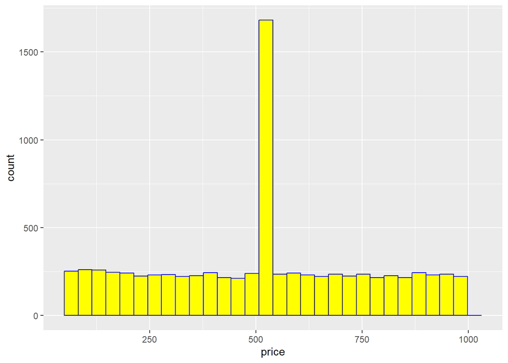

```r
   ggplot(project1_data,aes(x=price))+geom_histogram(color="blue",fill="yellow")
```

Scatter Plot of ‘Price’ vs ‘Total Revenue’:

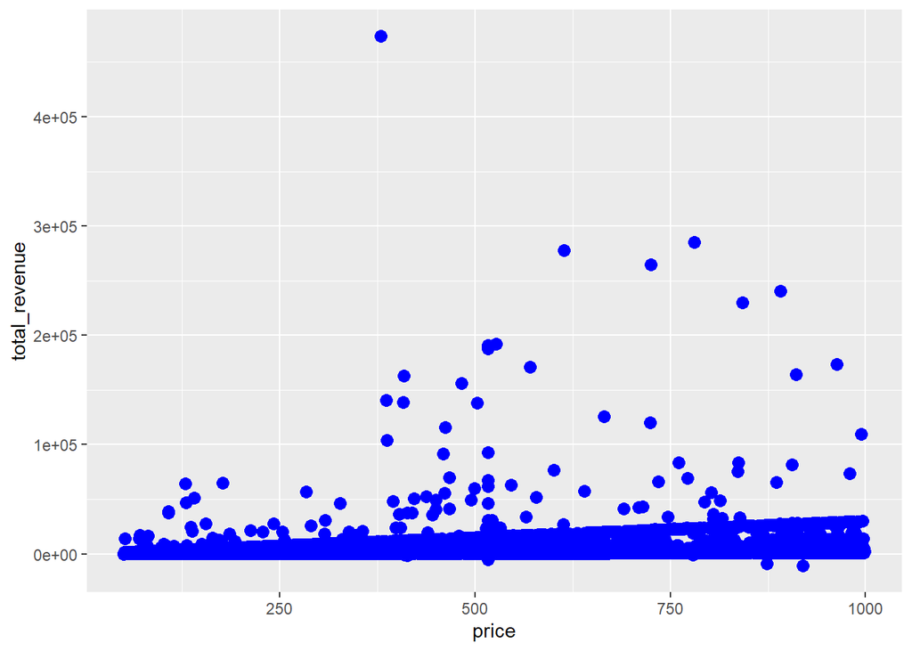

```r
   ggplot(project1_data, aes(x = price, y = total_revenue)) +
   geom_point(color = "blue", size = 3)
```

```r
   labs(title = "Price vs Total Revenue", x = "Price", y = "Total Revenue") +
   theme_minimal()
```

Boxplot of ‘service.fee’ by ‘room type’

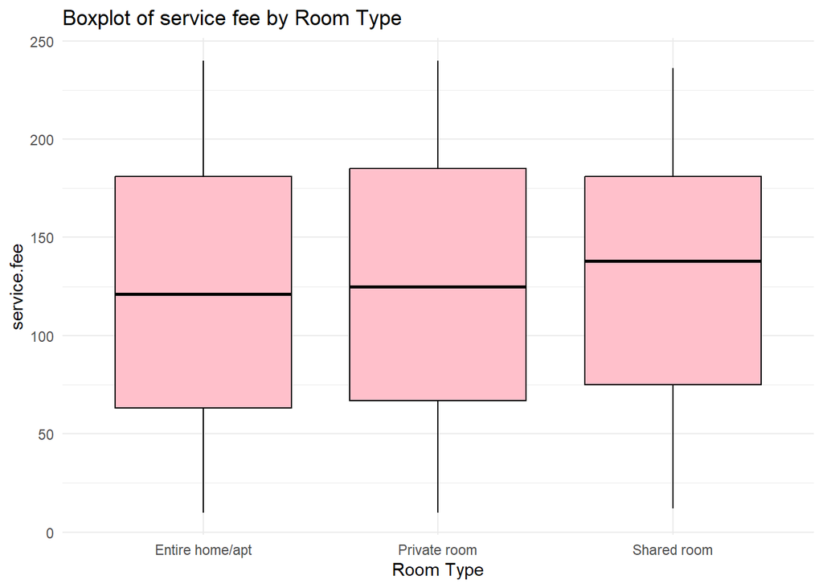

```r
   project1_data <- project1_data %>%
   mutate(room.type = as.factor(room.type),
   service.fee = as.numeric(service.fee))

   ggplot(project1_data, aes(x = room.type, y = service.fee)) +
   geom_boxplot( color = "black",fill="pink") +
  labs(title = "Boxplot of service fee by Room Type", x = "Room Type",
       y =       "service.fee") +
     theme_minimal()
```

### 4. feature engineering

```r
 #load required package
   library(geosphere)
```

calculating distance from particular point

```r
# Define landmark coordinates (Times Square, Manhattan)
   landmark_lat <- 40.7580
   landmark_long <- -73.9855
   #calculating distance from times sqaure to each listing
   project1_data$distance_to_times_square <- distHaversine(matrix(c(landmark_long,            landmark_lat), nrow = 1),project1_data[, c("long", "lat")])
   # check in some
   project1_data$distance_to_times_square[1:100]
```

```
##   [1] 12351.7190   508.9351  5707.8826  1451.3283  8300.0347  8300.0347
##   [7]   768.4956  5111.1062  4977.3765  5303.6751  9988.3407  4930.1081
##  [13]  3026.5214  7939.5164  4906.7192  3918.5134 10611.2907  6869.0563
##  [19]  3610.6437  8900.6937  5755.3131  6678.1308  8516.2068   694.8212
##  [25]  8080.1123  9964.4376  3644.1216  1737.4418  3957.4554 11556.1094
##  [31]  4659.4487  3851.6865 12114.3171  8710.0025  7172.2558  8428.7737
##  [37]  3826.5955  3924.5922 14735.5384  8088.1261  9315.9335  6085.5892
##  [43]  5278.5809  5562.2253  7530.0758  2900.9382  9503.9081  5191.5919
##  [49]  8972.3826 14911.5841  8107.9894  9428.5147  5502.0718  3679.3354
##  [55]  6191.7321  7558.4875  2761.2818  7118.1358  3097.8107  8370.0312
##  [61]  7756.1636  9533.8934  5731.2564  8708.9097  9327.7936  5866.0562
##  [67]  6111.4386  9364.4908  3405.4495  7999.5426  3394.4773  3960.8360
##  [73]  3318.6522  1024.7514  3132.4468  1970.8429  6723.0271  8288.6857
##  [79] 11077.0418  3016.7864  4172.3842  9424.0783  3446.3568  4572.9625
##  [85]  6921.2594  2031.7939  5572.8149  4868.5324  1394.9972  4082.9121
##  [91]  6287.7413  2430.1126  8822.5876  3183.1421  5986.7298  6409.1217
##  [97]  8662.7933  9497.6003  8886.3507 10133.5687
```

Calculate price per minimum night

```r
   project1_data$price_per_min_night <- as.numeric(gsub("[$,]", "", project1_data$price)) / project1_data$minimum.nights
#print price per minimum night
      print(project1_data$price_per_min_night[1:100])
```

```
##   [1]  96.6000000   4.7333333  20.4000000 192.3333333   1.5777778  11.4796741
##   [7] 258.2926666 145.5000000 319.0000000 121.2000000 145.0000000  74.5000000
##  [13]   6.4222222 258.2926666 516.5853332 281.5000000 123.3333333  98.1428571
##  [19] 214.0000000 363.0000000  19.6333333 419.5000000  17.6000000  33.0000000
##  [25] 380.5000000  21.0333333 338.5000000 114.8000000 129.1463333 258.2926666
##  [31] 659.0000000 114.2000000  49.0666667 315.3333333 149.6666667 310.0000000
##  [37]  65.8000000 172.1951111  48.0000000 516.5853332 593.0000000 172.0000000
##  [43] 129.1463333 172.1951111  20.2500000 236.0000000  33.6666667  37.6666667
##  [49]   3.0842491   3.9433995   1.8290909   1.4953560   2.9830508   1.8686869
##  [55]   1.4440299 -51.6585333   3.5185185   5.8333333   1.2000000   4.6953125
##  [61]   0.3057143   4.3614458   4.0909091   2.3028169 538.0000000  50.4000000
##  [67] 258.2926666 258.2926666 258.2926666 148.0000000 516.5853332 259.0000000
##  [73] 132.0000000 271.0000000  37.0000000 454.0000000 274.3333333 186.0000000
##  [79]  42.0000000  34.4285714  18.0000000  46.8571429 254.5000000 129.1463333
##  [85] 516.5853332 297.5000000  36.8989524 239.0000000   0.4050000 280.6666667
##  [91] 258.2926666 258.2926666  73.6000000 121.4285714  51.6585333 875.0000000
##  [97] 953.0000000 720.0000000 387.0000000 662.0000000
```

Convert date strings to Date class

```r
   project1_data$last.review <- as.Date(project1_data$last.review, format="%m/%d/%Y")
   project1_data$last.review[1:50]
```

```
##  [1] "2021-10-19" "2022-05-21" "2018-11-19" "2019-06-22" NA
##  [6] NA           "2019-06-24" "2017-07-21" NA           "2019-06-22"
## [11] "2019-06-24" NA           "2018-10-31" "2019-06-22" NA
## [16] "2019-06-21" "2019-05-27" "2018-09-30" "2019-06-16" NA
## [21] "2018-05-26" "2019-06-23" "2017-03-17" "2019-06-16" NA
## [26] "2018-12-30" NA           NA           NA           NA
## [31] "2021-09-18" "2024-08-15" "2017-08-17" "2019-05-14" "2019-06-20"
## [36] NA           "2019-06-25" "2019-05-20" NA           "2019-06-24"
## [41] "2019-06-23" NA           "2019-06-17" "2019-06-22" "2019-06-29"
## [46] "2019-06-22" NA           "2019-06-13" "2019-06-18" "2019-06-13"
```

### 6 Modeling Evaluation

load required package

```r
library(caTools)
library(caret)
library(randomForest)
```

split data into ‘Training data’ and ‘testing data’

```r
split= sample.split(project1_data$host_identity_verified, SplitRatio = 0.8)

   training_data=subset(project1_data,split==TRUE)
   #view training data
   View(training_data)
```

```r
   test_data=subset(project1_data,split==FALSE)
   # view testing data
   View(test_data)
```

### Train of models

Train ‘Linear Regression model’

```r
   lm_model <-lm(price ~ service.fee + total_revenue + long, data = training_data)
   summary(lm_model)
```

```
##
## Call:
## lm(formula = price ~ service.fee + total_revenue + long, data = training_data)
##
## Residuals:
##     Min      1Q  Median      3Q     Max
## -534.65 -113.73   10.56  139.21  500.67
##
## Coefficients:
##                Estimate Std. Error t value Pr(>|t|)
## (Intercept)   2.250e+03  4.206e+03   0.535    0.593
## service.fee   2.787e+00  3.074e-02  90.660  < 2e-16 ***
## total_revenue 1.129e-03  1.602e-04   7.049 1.99e-12 ***
## long          2.815e+01  5.687e+01   0.495    0.621
## ---
## Signif. codes:  0 '***' 0.001 '**' 0.01 '*' 0.05 '.' 0.1 ' ' 1
##
## Residual standard error: 166.4 on 6562 degrees of freedom
## Multiple R-squared:  0.5619, Adjusted R-squared:  0.5617
## F-statistic:  2806 on 3 and 6562 DF,  p-value: < 2.2e-16
```

Train ‘Random Forest Model’

```r
   rf_model <- randomForest(price ~ service.fee + total_revenue+long, data = training_data, method = "rf")
   print(rf_model)
```

```
##
## Call:
##  randomForest(formula = price ~ service.fee + total_revenue +      long, data = training_data, method = "rf")
##                Type of random forest: regression
##                      Number of trees: 500
## No. of variables tried at each split: 1
##
##           Mean of squared residuals: 562.0737
##                     % Var explained: 99.11
```

Train ‘Decision Tree’

```r
   library(rpart)
dt_model <- rpart(price ~ service.fee+ total_revenue, data = training_data, method = "anova")

print(dt_model)
```

```
## n= 6566
##
## node), split, n, deviance, yval
##       * denotes terminal node
##
##  1) root 6566 4.145829e+08 517.3596
##    2) service.fee< 91.5 2363 3.333420e+07 247.7248
##      4) service.fee< 49.5 1194 4.161284e+06 146.3125 *
##      5) service.fee>=49.5 1169 4.351052e+06 351.3058 *
##    3) service.fee>=91.5 4203 1.128644e+08 668.9530
##      6) service.fee>=200.5 1127 1.179857e-21 516.5853 *
##      7) service.fee< 200.5 3076 7.711391e+07 724.7782
##       14) service.fee< 144.5 1506 9.890967e+06 588.4590
##         28) service.fee< 118.5 776 2.211254e+06 523.9900 *
##         29) service.fee>=118.5 730 1.025981e+06 656.9904 *
##       15) service.fee>=144.5 1570 1.239201e+07 855.5404
##         30) service.fee< 169.5 700 1.163950e+06 783.4233 *
##         31) service.fee>=169.5 870 4.658223e+06 913.5657 *
```

### Prediction on data

‘Predication’ using ‘Liner Model’ on test data

```r
   lm_predictions <- predict(lm_model, test_data)
#show some cols of prediction out of 10k rows
   print(lm_predictions[1:100])
```

```
##        9       39       41      117      126      127      129      131
## 736.9505 780.3691 730.6744 491.1433 787.7981 536.4547 590.9171 420.6326
##      133      148      170      177      183      218      222      227
## 352.8920 348.6973 894.5507 805.5806 709.5199 459.0323 388.7277 271.7968
##      233      276      280      281      284      297      302      306
## 838.1545 795.5827 734.1907 657.0415 382.0410 707.4316 202.8701 206.6070
##      311      354      360      368      370      372      373      379
## 202.1476 198.9672 541.7996 476.8615 458.0099 821.3425 591.4833 648.8873
##      383      398      399      443      475      479      495      496
## 555.1686 241.5826 601.4906 654.1957 485.3087 395.0060 498.8798 371.5604
##      513      514      528      532      538      551      557      572
## 757.1032 474.6823 360.8651 266.9256 310.8262 628.8142 449.1826 303.0926
##      642      643      645      661      669      699      700      707
## 748.0463 812.8289 318.9288 468.4704 875.2908 708.4031 589.2130 696.1789
##      721      739      741      742      744      745      746      750
## 285.9802 593.7424 496.4584 540.3422 264.9432 208.0377 515.2268 770.7892
##      769      776      797      802      807      812      820      831
## 234.2980 731.8138 632.5236 350.2370 535.6851 325.8141 280.2329 830.3673
##      834      842      851      855      866      875      879      880
## 454.1185 799.3287 445.3716 273.2196 757.3166 393.2003 821.5069 587.9806
##      881      888      895      896      909      914      918      942
## 663.7488 410.7586 661.0322 453.3341 253.7599 263.7158 767.5679 462.4577
##      949      953      964      966      968      973      986      989
## 502.3190 509.4752 642.1356 579.7072 362.2742 545.9508 683.6193 687.1468
##      995      996     1010     1017
## 789.2553 426.5111 488.7658 379.5502
```

‘Prediction’ on the test data using ‘Random Forest Model’

```r
   rf_predictions <- predict(rf_model, test_data)
#show some cols of prediction out of 10k rows
   print(rf_predictions[1:100])
```

```
##         9        39        41       117       126       127       129       131
## 517.05293 516.58533 516.58950 595.06709 516.58533 658.86523 725.40837 448.46899
##       133       148       170       177       183       218       222       227
## 341.70107 327.88767 805.33619 537.53801 722.50266 521.94724 395.41504 184.37104
##       233       276       280       281       284       297       302       306
## 517.27616 516.91249 539.73942 869.05366 378.84353 945.82516  96.57483  70.07176
##       311       354       360       368       370       372       373       379
## 141.62141  56.59927 667.99749 560.55507 495.11397 516.64958 751.74956 836.44027
##       383       398       399       443       475       479       495       496
## 693.01024 127.54281 493.54997 813.17017 571.49315 297.77184 595.16104 365.91016
##       513       514       528       532       538       551       557       572
## 516.58533 553.84807 347.01018 173.37991 252.37966 824.74407 520.16000 236.49694
##       642       643       645       661       669       699       700       707
## 517.16777 517.31295 258.74618 537.01088 532.56337 956.90768 745.11121 911.59464
##       721       739       741       742       744       745       746       750
## 188.42030 738.01457 592.08530 663.33723 178.05088  77.37200 621.25385 517.51096
##       769       776       797       802       807       812       820       831
## 126.70080 529.32447 823.44499 319.88438 650.64834 278.56347 211.41355 518.01091
##       834       842       851       855       866       875       879       880
## 518.25791 517.04267 509.69115 180.06213 516.58533 395.39574 517.09644 715.64167
##       881       888       895       896       909       914       918       942
## 883.53540 434.27837 840.38285 508.84074 173.95699 174.11599 517.70302 536.23837
##       949       953       964       966       968       973       986       989
## 609.53240 610.50335 835.33138 729.57755 339.81565 673.81484 905.97851 915.79826
##       995       996      1010      1017
## 517.82953 473.20415 541.77977 382.23890
```

‘Prediction’ on test data using ‘Decision Tree’

```r
#prediction on test data using decision tree
   dt_predictions <- predict(dt_model, test_data)
#show some cols of prediction out of 10k rows
   print(dt_predictions[1:100])
```

```
##        9       39       41      117      126      127      129      131
## 516.5853 516.5853 516.5853 523.9900 516.5853 656.9904 783.4233 351.3058
##      133      148      170      177      183      218      222      227
## 351.3058 351.3058 783.4233 516.5853 783.4233 523.9900 351.3058 146.3125
##      233      276      280      281      284      297      302      306
## 516.5853 516.5853 516.5853 913.5657 351.3058 913.5657 146.3125 146.3125
##      311      354      360      368      370      372      373      379
## 146.3125 146.3125 656.9904 523.9900 523.9900 516.5853 783.4233 913.5657
##      383      398      399      443      475      479      495      496
## 656.9904 146.3125 783.4233 783.4233 523.9900 351.3058 523.9900 351.3058
##      513      514      528      532      538      551      557      572
## 516.5853 523.9900 351.3058 146.3125 351.3058 783.4233 523.9900 146.3125
##      642      643      645      661      669      699      700      707
## 516.5853 516.5853 351.3058 523.9900 516.5853 913.5657 783.4233 913.5657
##      721      739      741      742      744      745      746      750
## 146.3125 783.4233 523.9900 656.9904 146.3125 146.3125 656.9904 516.5853
##      769      776      797      802      807      812      820      831
## 146.3125 516.5853 783.4233 351.3058 656.9904 351.3058 146.3125 516.5853
##      834      842      851      855      866      875      879      880
## 523.9900 516.5853 523.9900 146.3125 516.5853 351.3058 516.5853 783.4233
##      881      888      895      896      909      914      918      942
## 913.5657 351.3058 783.4233 523.9900 146.3125 146.3125 516.5853 523.9900
##      949      953      964      966      968      973      986      989
## 656.9904 656.9904 783.4233 783.4233 351.3058 656.9904 913.5657 913.5657
##      995      996     1010     1017
## 516.5853 523.9900 523.9900 351.3058
```

### Calculating ‘RMSE’ for each training model

```r
# download required package
library(Metrics)
```

‘Calculating RMSE’ for each training model

```r
   lm_rmse<-rmse(test_data$price, lm_predictions)
   rf_rmse<-rmse(test_data$price,rf_predictions)
   dt_rmse<-rmse(test_data$price,dt_predictions)
```

‘Print RMSE’ value of all models

```r
   cat("liner model  RMSE:", lm_rmse, "\n")
```

```
## liner model  RMSE: 167.55
```

```r
   cat("random forest model RMSE:", rf_rmse, "\n")
```

```
## random forest model RMSE: 20.9042
```

```r
   cat("decision tree RMSE:", dt_rmse, "\n")
```

```
## decision tree RMSE: 50.11181
```

### Visualization of all predicted models

Plot Liner Model predictions

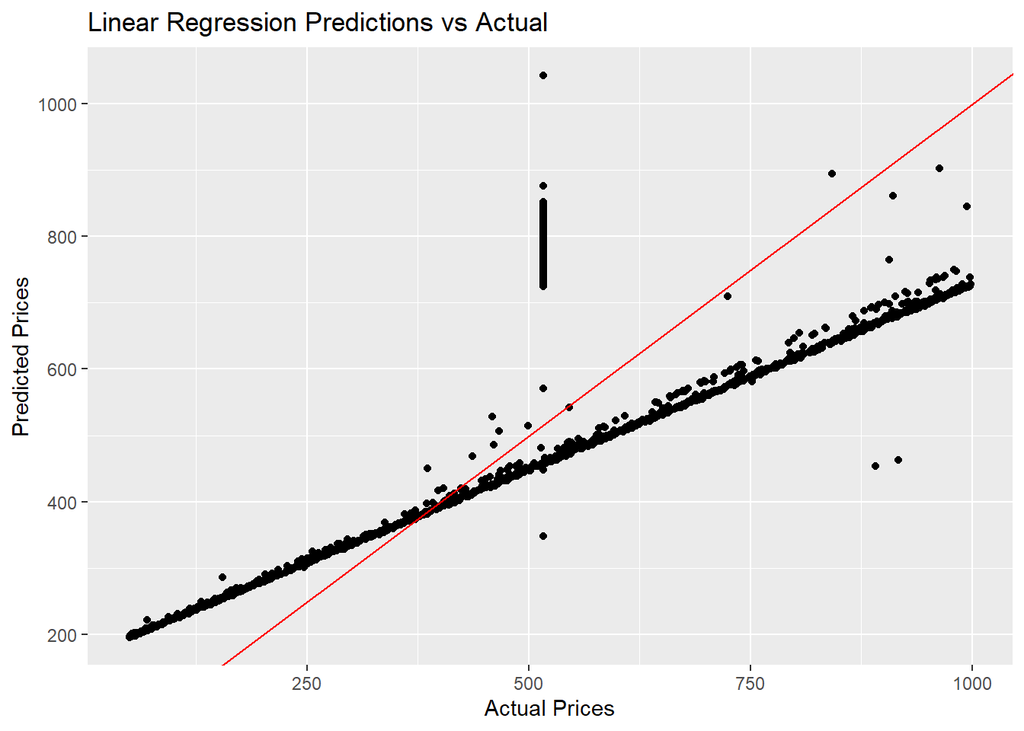

```r
  ggplot(test_data, aes(x = price, y = lm_predictions)) +
     geom_point() +
     geom_abline(slope = 1, intercept = 0, col = "red") +
     labs(title = "Linear Regression Predictions vs Actual", x = "Actual Prices", y = "Predicted Prices")
```

Plot Random Forest predictions

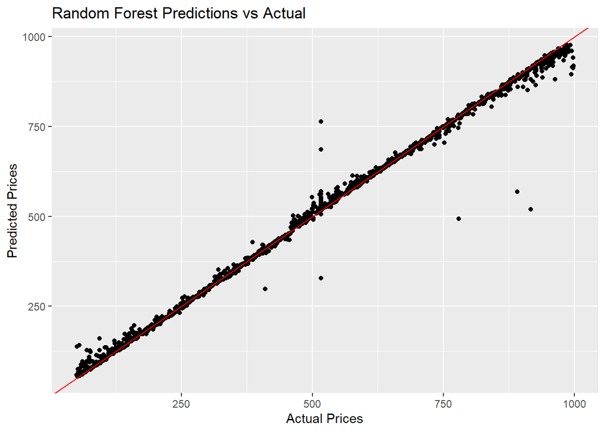

```r
ggplot(test_data, aes(x = price, y = rf_predictions)) +
geom_point() +
geom_abline(slope = 1, intercept = 0, col = "red") +
labs(title = "Random Forest Predictions vs Actual", x = "Actual Prices", y = "Predicted Prices")
```

### Plot decision tree predictions

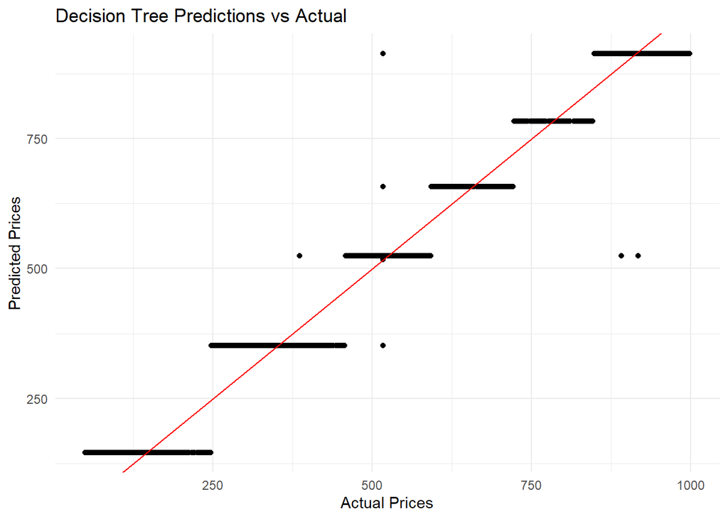

```r
  ggplot(test_data, aes(x = price, y = dt_predictions)) +
  geom_point() +
  geom_abline(slope = 1, intercept = 0, col = "red") +
  labs(title = "Decision Tree Predictions vs Actual", x = "Actual Prices", y = "Predicted Prices") +
  theme_minimal()
```